# Procesamiento y Visualización

Ejercicio: procesar datos de expresión génica descargados desde NCBI GEO, llevar dichos datos a un formato que nos permita fácilmente su visualización usando ggplot2.

Para este ejercicio vamos a necesitar una serie de paquetes de R:

- Procesamiento y transformación de los datos:
  - R.utils para descomprimir archivos,
  - dplyr para manipulación, selección, etc.
  - tidyr para cambiar el formato de los datos (wide a long)
- Acceso a los metadatos del conjunto de datos: GEOquery

# Instalación y carga de las librerías necesarias

```r
list.of.packages = c("dplyr","ggplot2","tidyr", "R.utils")
list.of.packages_Bio = c("GEOquery")
list.of.packages
```

```
[1] "dplyr"   "ggplot2" "tidyr"   "R.utils"
```

```r
list.of.packages_Bio
```

```
[1] "GEOquery"
```

```r
new.packages = list.of.packages[!(list.of.packages %in% installed.packages())]
if(length(new.packages)> 0) install.packages(new.packages)

new.packages = list.of.packages_Bio[!(list.of.packages_Bio %in% installed.packages())]
if(length(new.packages)> 0) BiocManager::install(new.packages,version = BiocManager::version())

invisible(lapply(list.of.packages, FUN=library, character.only=TRUE))
invisible(lapply(list.of.packages_Bio, FUN=library, character.only=TRUE))
```

```
Setting options('download.file.method.GEOquery'='auto')
Setting options('GEOquery.inmemory.gpl'=FALSE)
```

# Descarga del conjunto de datos

```r
URL="https://www.ncbi.nlm.nih.gov/geo/download/?acc=GSE183947&format=file&file=GSE183947%5Ffpkm%2Ecsv%2Egz"

# Si el archivo existe en el directorio de trabajo, lo eliminamos con la función unlink()
unlink("GSE183947_fpkm.csv.gz")

# Descarga del archivo usando URL y almacenamiento en nuestro directorio de trabajo
# usando como nombre lo que indicamos en el argumento destfile
download.file(URL,destfile="GSE183947_fpkm.csv.gz")
# El archivo descargado es comprimido con extensión .gz
# En caso de existir el archivo descomprimido, lo eliminamos
unlink("GSE183947_fpkm.csv")

# Descompresión del archivo
gunzip("GSE183947_fpkm.csv.gz")
```

Importar datos

```r
data = read.csv(file="GSE183947_fpkm.csv")
dim(data)
```

```
[1] 20246    61
```

```r
gse = getGEO(GEO="GSE183947", GSEMatrix=TRUE)
```

```
Found 1 file(s)
GSE183947_series_matrix.txt.gz
```

```r
Sys.setenv("VROOM_CONNECTION_SIZE"=131072*1000)
gse = getGEO(GEO="GSE183947", GSEMatrix=TRUE)
```

```
Found 1 file(s)
GSE183947_series_matrix.txt.gz
Using locally cached version: /var/folders/r3/64rpy82j0139lttf0s4k2rtc0000gn/T//RtmpfQPaek/GSE183947_series_matrix.txt.gz
Using locally cached version of GPL11154 found here:
/var/folders/r3/64rpy82j0139lttf0s4k2rtc0000gn/T//RtmpfQPaek/GPL11154.soft.gz
```

```r
gse
```

```
$GSE183947_series_matrix.txt.gz
ExpressionSet (storageMode: lockedEnvironment)
assayData: 0 features, 60 samples
  element names: exprs
protocolData: none
phenoData
  sampleNames: GSM5574685 GSM5574686 ... GSM5574744 (60 total)
  varLabels: title geo_accession ... tissue:ch1 (41 total)
  varMetadata: labelDescription
featureData: none
experimentData: use 'experimentData(object)'
  pubMedIds: 35046993
Annotation: GPL11154
```

Extracción de información de los metadatos

```r
metadata = pData(phenoData(gse[[1]]))
head(metadata)
```

|  | title | geo_accession | status | submission_date | last_update_date | type | channel_count | source_name_ch1 | organism_ch1 | characteristics_ch1 | characteristics_ch1.1 | characteristics_ch1.2 | molecule_ch1 | extract_protocol_ch1 | extract_protocol_ch1.1 | taxid_ch1 | description | data_processing | data_processing.1 | data_processing.2 | data_processing.3 | data_processing.4 | platform_id | contact_name | contact_institute | contact_address | contact_city | contact_state | contact_zip/postal_code | … |
| --- | --- | --- | --- | --- | --- | --- | --- | --- | --- | --- | --- | --- | --- | --- | --- | --- | --- | --- | --- | --- | --- | --- | --- | --- | --- | --- | --- | --- | --- | --- |
| GSM5574685 | tumor rep1 | GSM5574685 | Public on Sep 15 2021 | Sep 11 2021 | Sep 15 2021 | SRA | 1 | breast | Homo sapiens | tissue: breast tumor | metastasis: yes | donor: 102548 | total RNA | Total RNA was isolated and purified using TRIzol (Life, cat.265709, CA, USA) following the manufacturer's procedure. | After the quality inspection of Agilent 2100 Bioanalyzer (Agilent, cat.G2939AA, CA, USA) and NanoPhotometer (Implen, cat.N60, Munich, Germany), mRNA with poly(A) is purified from 1μg total RNA using V… | 9606 | CA.102548 | In order to remove technical sequences, including adapters, polymerase chain reaction (PCR) primers, or fragments thereof, and quality of bases lower than 20, pass filter data of fastq format were pro… | Firstly, reference genome sequences and gene model annotation files of relative species were downloaded from genome ENSEMBL website, Tophat2 (v2.1.0) was used to index reference genome sequence. Final… | In the beginning transcripts in fasta format are converted from known gff annotation file and indexed properly. Then, with the file as a reference gene file, RSEM (v1.3.1) estimated gene and isoform e… | Genome_build: Homo sapiens (GRCh37) | Supplementary_files_format_and_content: fpkm.csv: Comma-separated text file includes FPKM values for each Sample. | GPL11154 | Jianhua,,Xu | Department of Laboratory Medicine Shunde Hospital of Guangzhou University of Chinese Medicine | No. 12, Jinsha Avenue, Shunde District, Foshan, Guangdong, P.R. China | Fushan | Guangdong | 528300 | … |
| GSM5574686 | tumor rep2 | GSM5574686 | Public on Sep 15 2021 | Sep 11 2021 | Sep 15 2021 | SRA | 1 | breast | Homo sapiens | tissue: breast tumor | metastasis: yes | donor: 104338 | total RNA | Total RNA was isolated and purified using TRIzol (Life, cat.265709, CA, USA) following the manufacturer's procedure. | After the quality inspection of Agilent 2100 Bioanalyzer (Agilent, cat.G2939AA, CA, USA) and NanoPhotometer (Implen, cat.N60, Munich, Germany), mRNA with poly(A) is purified from 1μg total RNA using V… | 9606 | CA.104338 | In order to remove technical sequences, including adapters, polymerase chain reaction (PCR) primers, or fragments thereof, and quality of bases lower than 20, pass filter data of fastq format were pro… | Firstly, reference genome sequences and gene model annotation files of relative species were downloaded from genome ENSEMBL website, Tophat2 (v2.1.0) was used to index reference genome sequence. Final… | In the beginning transcripts in fasta format are converted from known gff annotation file and indexed properly. Then, with the file as a reference gene file, RSEM (v1.3.1) estimated gene and isoform e… | Genome_build: Homo sapiens (GRCh37) | Supplementary_files_format_and_content: fpkm.csv: Comma-separated text file includes FPKM values for each Sample. | GPL11154 | Jianhua,,Xu | Department of Laboratory Medicine Shunde Hospital of Guangzhou University of Chinese Medicine | No. 12, Jinsha Avenue, Shunde District, Foshan, Guangdong, P.R. China | Fushan | Guangdong | 528300 | … |
| GSM5574687 | tumor rep3 | GSM5574687 | Public on Sep 15 2021 | Sep 11 2021 | Sep 15 2021 | SRA | 1 | breast | Homo sapiens | tissue: breast tumor | metastasis: yes | donor: 105094 | total RNA | Total RNA was isolated and purified using TRIzol (Life, cat.265709, CA, USA) following the manufacturer's procedure. | After the quality inspection of Agilent 2100 Bioanalyzer (Agilent, cat.G2939AA, CA, USA) and NanoPhotometer (Implen, cat.N60, Munich, Germany), mRNA with poly(A) is purified from 1μg total RNA using V… | 9606 | CA.105094 | In order to remove technical sequences, including adapters, polymerase chain reaction (PCR) primers, or fragments thereof, and quality of bases lower than 20, pass filter data of fastq format were pro… | Firstly, reference genome sequences and gene model annotation files of relative species were downloaded from genome ENSEMBL website, Tophat2 (v2.1.0) was used to index reference genome sequence. Final… | In the beginning transcripts in fasta format are converted from known gff annotation file and indexed properly. Then, with the file as a reference gene file, RSEM (v1.3.1) estimated gene and isoform e… | Genome_build: Homo sapiens (GRCh37) | Supplementary_files_format_and_content: fpkm.csv: Comma-separated text file includes FPKM values for each Sample. | GPL11154 | Jianhua,,Xu | Department of Laboratory Medicine Shunde Hospital of Guangzhou University of Chinese Medicine | No. 12, Jinsha Avenue, Shunde District, Foshan, Guangdong, P.R. China | Fushan | Guangdong | 528300 | … |
| GSM5574688 | tumor rep4 | GSM5574688 | Public on Sep 15 2021 | Sep 11 2021 | Sep 15 2021 | SRA | 1 | breast | Homo sapiens | tissue: breast tumor | metastasis: no | donor: 109745 | total RNA | Total RNA was isolated and purified using TRIzol (Life, cat.265709, CA, USA) following the manufacturer's procedure. | After the quality inspection of Agilent 2100 Bioanalyzer (Agilent, cat.G2939AA, CA, USA) and NanoPhotometer (Implen, cat.N60, Munich, Germany), mRNA with poly(A) is purified from 1μg total RNA using V… | 9606 | CA.109745 | In order to remove technical sequences, including adapters, polymerase chain reaction (PCR) primers, or fragments thereof, and quality of bases lower than 20, pass filter data of fastq format were pro… | Firstly, reference genome sequences and gene model annotation files of relative species were downloaded from genome ENSEMBL website, Tophat2 (v2.1.0) was used to index reference genome sequence. Final… | In the beginning transcripts in fasta format are converted from known gff annotation file and indexed properly. Then, with the file as a reference gene file, RSEM (v1.3.1) estimated gene and isoform e… | Genome_build: Homo sapiens (GRCh37) | Supplementary_files_format_and_content: fpkm.csv: Comma-separated text file includes FPKM values for each Sample. | GPL11154 | Jianhua,,Xu | Department of Laboratory Medicine Shunde Hospital of Guangzhou University of Chinese Medicine | No. 12, Jinsha Avenue, Shunde District, Foshan, Guangdong, P.R. China | Fushan | Guangdong | 528300 | … |
| GSM5574689 | tumor rep5 | GSM5574689 | Public on Sep 15 2021 | Sep 11 2021 | Sep 15 2021 | SRA | 1 | breast | Homo sapiens | tissue: breast tumor | metastasis: no | donor: 1906415 | total RNA | Total RNA was isolated and purified using TRIzol (Life, cat.265709, CA, USA) following the manufacturer's procedure. | After the quality inspection of Agilent 2100 Bioanalyzer (Agilent, cat.G2939AA, CA, USA) and NanoPhotometer (Implen, cat.N60, Munich, Germany), mRNA with poly(A) is purified from 1μg total RNA using V… | 9606 | CA.1906415 | In order to remove technical sequences, including adapters, polymerase chain reaction (PCR) primers, or fragments thereof, and quality of bases lower than 20, pass filter data of fastq format were pro… | Firstly, reference genome sequences and gene model annotation files of relative species were downloaded from genome ENSEMBL website, Tophat2 (v2.1.0) was used to index reference genome sequence. Final… | In the beginning transcripts in fasta format are converted from known gff annotation file and indexed properly. Then, with the file as a reference gene file, RSEM (v1.3.1) estimated gene and isoform e… | Genome_build: Homo sapiens (GRCh37) | Supplementary_files_format_and_content: fpkm.csv: Comma-separated text file includes FPKM values for each Sample. | GPL11154 | Jianhua,,Xu | Department of Laboratory Medicine Shunde Hospital of Guangzhou University of Chinese Medicine | No. 12, Jinsha Avenue, Shunde District, Foshan, Guangdong, P.R. China | Fushan | Guangdong | 528300 | … |
| GSM5574690 | tumor rep6 | GSM5574690 | Public on Sep 15 2021 | Sep 11 2021 | Sep 15 2021 | SRA | 1 | breast | Homo sapiens | tissue: breast tumor | metastasis: yes | donor: 1912627 | total RNA | Total RNA was isolated and purified using TRIzol (Life, cat.265709, CA, USA) following the manufacturer's procedure. | After the quality inspection of Agilent 2100 Bioanalyzer (Agilent, cat.G2939AA, CA, USA) and NanoPhotometer (Implen, cat.N60, Munich, Germany), mRNA with poly(A) is purified from 1μg total RNA using V… | 9606 | CA.1912627 | In order to remove technical sequences, including adapters, polymerase chain reaction (PCR) primers, or fragments thereof, and quality of bases lower than 20, pass filter data of fastq format were pro… | Firstly, reference genome sequences and gene model annotation files of relative species were downloaded from genome ENSEMBL website, Tophat2 (v2.1.0) was used to index reference genome sequence. Final… | In the beginning transcripts in fasta format are converted from known gff annotation file and indexed properly. Then, with the file as a reference gene file, RSEM (v1.3.1) estimated gene and isoform e… | Genome_build: Homo sapiens (GRCh37) | Supplementary_files_format_and_content: fpkm.csv: Comma-separated text file includes FPKM values for each Sample. | GPL11154 | Jianhua,,Xu | Department of Laboratory Medicine Shunde Hospital of Guangzhou University of Chinese Medicine | No. 12, Jinsha Avenue, Shunde District, Foshan, Guangdong, P.R. China | Fushan | Guangdong | 528300 | … |

```r
View(metadata)
```

Procesamiento y manipulación de los Datos

```r
metadata %>%
  select(c(1,10,11,17)) %>%
  head()
```

|  | title | characteristics_ch1 | characteristics_ch1.1 | description |
| --- | --- | --- | --- | --- |
| GSM5574685 | tumor rep1 | tissue: breast tumor | metastasis: yes | CA.102548 |
| GSM5574686 | tumor rep2 | tissue: breast tumor | metastasis: yes | CA.104338 |
| GSM5574687 | tumor rep3 | tissue: breast tumor | metastasis: yes | CA.105094 |
| GSM5574688 | tumor rep4 | tissue: breast tumor | metastasis: no | CA.109745 |
| GSM5574689 | tumor rep5 | tissue: breast tumor | metastasis: no | CA.1906415 |
| GSM5574690 | tumor rep6 | tissue: breast tumor | metastasis: yes | CA.1912627 |

```r
NA
```

```r
metadata %>%
  select(c(1,10,11,17)) %>%
  rename(tissue = characteristics_ch1) %>%
  rename(metastasis = characteristics_ch1.1) %>%
  head()
```

|  | title | tissue | metastasis | description |
| --- | --- | --- | --- | --- |
| GSM5574685 | tumor rep1 | tissue: breast tumor | metastasis: yes | CA.102548 |
| GSM5574686 | tumor rep2 | tissue: breast tumor | metastasis: yes | CA.104338 |
| GSM5574687 | tumor rep3 | tissue: breast tumor | metastasis: yes | CA.105094 |
| GSM5574688 | tumor rep4 | tissue: breast tumor | metastasis: no | CA.109745 |
| GSM5574689 | tumor rep5 | tissue: breast tumor | metastasis: no | CA.1906415 |
| GSM5574690 | tumor rep6 | tissue: breast tumor | metastasis: yes | CA.1912627 |

```r
metadata %>%
  select(c(1,10,11,17)) %>%
  rename(tissue = characteristics_ch1) %>%
  rename(metastasis = characteristics_ch1.1) %>%
  mutate(tissue = gsub("tissue: ","",tissue)) %>%
  head
```

|  | title | tissue | metastasis | description |
| --- | --- | --- | --- | --- |
| GSM5574685 | tumor rep1 | breast tumor | metastasis: yes | CA.102548 |
| GSM5574686 | tumor rep2 | breast tumor | metastasis: yes | CA.104338 |
| GSM5574687 | tumor rep3 | breast tumor | metastasis: yes | CA.105094 |
| GSM5574688 | tumor rep4 | breast tumor | metastasis: no | CA.109745 |
| GSM5574689 | tumor rep5 | breast tumor | metastasis: no | CA.1906415 |
| GSM5574690 | tumor rep6 | breast tumor | metastasis: yes | CA.1912627 |

```r
metadata %>%
  select(c(1,10,11,17)) %>%
  rename(tissue = characteristics_ch1) %>%
  rename(metastasis = characteristics_ch1.1) %>%
  mutate(tissue = gsub("tissue: ","",tissue)) %>%
  mutate(metastasis = gsub("metastasis: ","",metastasis)) %>%
  head()
```

|  | title | tissue | metastasis | description |
| --- | --- | --- | --- | --- |
| GSM5574685 | tumor rep1 | breast tumor | yes | CA.102548 |
| GSM5574686 | tumor rep2 | breast tumor | yes | CA.104338 |
| GSM5574687 | tumor rep3 | breast tumor | yes | CA.105094 |
| GSM5574688 | tumor rep4 | breast tumor | no | CA.109745 |
| GSM5574689 | tumor rep5 | breast tumor | no | CA.1906415 |
| GSM5574690 | tumor rep6 | breast tumor | yes | CA.1912627 |

Una vez comprobado que todo esté correcto salvamos el resultado en un objeto metadata.modified

```r
# creamos un nuevo data frame modificado con lo anterior, no es que modifiquemos el metadata inicial
metadata.modified = metadata %>%
  select(c(1,10,11,17)) %>%
  rename(tissue = characteristics_ch1) %>%
  rename(metastasis = characteristics_ch1.1) %>%
  mutate(tissue = gsub("tissue: ","",tissue)) %>%
  mutate(metastasis = gsub("metastasis: ","",metastasis))
```

Vamos a renombrar la variable/columna X a gene en data

```r
data %>%
  rename(gene = X) %>%
  head()
```

|  | gene | CA.102548 | CA.104338 | CA.105094 | CA.109745 | CA.1906415 | CA.1912627 | CA.1924346 | CA.1926760 | CA.1927842 | CA.1933414 | CA.1940640 | CA.2004407 | CA.2005288 | CA.2006047 | CA.2008260 | CA.2009329 | CA.2009381 | CA.2009850 | CA.2017611 | CA.2039179 | CA.2040686 | CA.2045012 | CA.2046297 | CA.348981 | CA.354300 | CA.359448 | CA.94377 | CA.98389 | … |
| --- | --- | --- | --- | --- | --- | --- | --- | --- | --- | --- | --- | --- | --- | --- | --- | --- | --- | --- | --- | --- | --- | --- | --- | --- | --- | --- | --- | --- | --- | --- |
| 1 | TSPAN6 | 0.93 | 1.97 | 0.00 | 5.45 | 4.52 | 4.75 | 3.96 | 3.58 | 6.41 | 11.89 | 5.55 | 3.82 | 7.66 | 11.48 | 4.32 | 14.44 | 10.26 | 6.51 | 5.86 | 7.13 | 9.19 | 6.65 | 10.13 | 7.07 | 4.76 | 2.10 | 4.77 | 5.04 | … |
| 2 | TNMD | 0.00 | 0.00 | 0.00 | 0.00 | 0.00 | 0.00 | 0.00 | 0.23 | 0.39 | 0.44 | 0.36 | 0.09 | 0.07 | 1.14 | 0.00 | 0.50 | 0.21 | 0.20 | 0.10 | 0.18 | 0.20 | 0.00 | 0.00 | 0.00 | 0.49 | 0.00 | 0.27 | 0.60 | … |
| 3 | DPM1 | 0.00 | 0.43 | 0.00 | 3.43 | 8.45 | 8.53 | 7.80 | 7.62 | 6.40 | 6.09 | 6.62 | 5.51 | 9.62 | 6.77 | 13.13 | 9.71 | 9.01 | 7.71 | 18.03 | 8.32 | 5.96 | 9.21 | 8.60 | 2.89 | 6.51 | 2.72 | 15.23 | 6.79 | … |
| 4 | SCYL3 | 5.78 | 5.17 | 8.76 | 4.58 | 7.20 | 6.03 | 9.05 | 5.37 | 5.92 | 12.45 | 10.44 | 8.81 | 9.04 | 9.36 | 5.91 | 4.58 | 8.10 | 13.55 | 3.66 | 4.39 | 7.46 | 9.98 | 15.58 | 8.54 | 4.42 | 4.82 | 5.76 | 8.15 | … |
| 5 | C1orf112 | 2.83 | 6.26 | 3.37 | 6.24 | 5.16 | 13.69 | 6.69 | 5.28 | 7.65 | 13.71 | 13.97 | 7.30 | 16.13 | 14.37 | 10.71 | 9.87 | 8.51 | 16.54 | 10.59 | 5.37 | 8.59 | 13.38 | 15.07 | 8.33 | 5.01 | 5.98 | 8.66 | 13.07 | … |
| 6 | FGR | 4.80 | 1.83 | 0.00 | 4.23 | 15.87 | 8.56 | 13.28 | 12.27 | 5.58 | 7.03 | 5.04 | 12.83 | 9.56 | 7.57 | 9.77 | 15.40 | 11.62 | 8.90 | 1.87 | 8.93 | 9.04 | 8.44 | 5.54 | 15.79 | 6.42 | 11.93 | 8.07 | 3.50 | … |

Vamos a transformar data de formato wide a formato long

```r
data %>%
  rename(gene = X) %>%
  gather(key="samples", value="FPKM", -gene) %>%
  head()
```

|  | gene | samples | FPKM |
| --- | --- | --- | --- |
| 1 | TSPAN6 | CA.102548 | 0.93 |
| 2 | TNMD | CA.102548 | 0.00 |
| 3 | DPM1 | CA.102548 | 0.00 |
| 4 | SCYL3 | CA.102548 | 5.78 |
| 5 | C1orf112 | CA.102548 | 2.83 |
| 6 | FGR | CA.102548 | 4.80 |

```r
NA
```

```r
data.long = data %>%
  rename(gene = X) %>%
  gather(key="samples", value="FPKM", -gene)
```

Una vez que tenemos los datos en formato long y los metadatos vamos a hacer una unión de los metadatos a nuestros datos de las muestras. Vamos a usar una función de la familia de funciones join

```r
# union de dos data frame con join
  left_join(data.long, metadata.modified, by=c("samples"="description")) %>%
  head(10)
```

|  | gene | samples | FPKM | title | tissue | metastasis |
| --- | --- | --- | --- | --- | --- | --- |
| 1 | TSPAN6 | CA.102548 | 0.93 | tumor rep1 | breast tumor | yes |
| 2 | TNMD | CA.102548 | 0.00 | tumor rep1 | breast tumor | yes |
| 3 | DPM1 | CA.102548 | 0.00 | tumor rep1 | breast tumor | yes |
| 4 | SCYL3 | CA.102548 | 5.78 | tumor rep1 | breast tumor | yes |
| 5 | C1orf112 | CA.102548 | 2.83 | tumor rep1 | breast tumor | yes |
| 6 | FGR | CA.102548 | 4.80 | tumor rep1 | breast tumor | yes |
| 7 | CFH | CA.102548 | 1.37 | tumor rep1 | breast tumor | yes |
| 8 | FUCA2 | CA.102548 | 21.92 | tumor rep1 | breast tumor | yes |
| 9 | GCLC | CA.102548 | 34.16 | tumor rep1 | breast tumor | yes |
| 10 | NFYA | CA.102548 | 0.70 | tumor rep1 | breast tumor | yes |

```r
data.long=left_join(data.long, metadata.modified, by=c("samples"="description"))
```

```r
data.long %>%
  filter(gene=="BRCA1" | gene == "BRCA2") %>%
  group_by(gene,tissue) %>%
  summarize(mean_FPKM=mean(FPKM), median_FPKM = median(FPKM)) %>%
  head()
```

| gene | tissue | mean_FPKM | median_FPKM |
| --- | --- | --- | --- |
| BRCA1 | breast tumor | 10.042333 | 6.965 |
| BRCA1 | normal breast tissue | 7.698667 | 6.450 |
| BRCA2 | breast tumor | 2.044000 | 1.600 |
| BRCA2 | normal breast tissue | 3.047333 | 1.250 |

```r
data.long %>%
  filter(gene=="BRCA1" | gene == "BRCA2") %>%
  group_by(gene,tissue) %>%
  summarize(mean_FPKM=mean(FPKM), median_FPKM = median(FPKM)) %>%
  arrange(mean_FPKM) %>%
  head()
```

| gene | tissue | mean_FPKM | median_FPKM |
| --- | --- | --- | --- |
| BRCA2 | breast tumor | 2.044000 | 1.600 |
| BRCA2 | normal breast tissue | 3.047333 | 1.250 |
| BRCA1 | normal breast tissue | 7.698667 | 6.450 |
| BRCA1 | breast tumor | 10.042333 | 6.965 |

Salvar data.long

```r
write.csv(data.long, "GSE183947_long.csv", row.names=FALSE)
```

```r
data.long=read.csv("GSE183947_long.csv")
```

Visualización

```r
ggplot(data, aes(x=variable1, y=variable2)) +
  geom_col()
```

Gráfico de barras

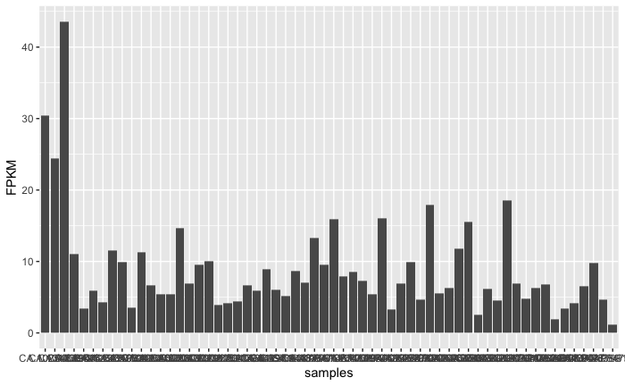

```r
data.long %>%
  filter(gene=="BRCA1") %>%
  ggplot(., aes(x=samples, y=FPKM)) +
  geom_col()
```

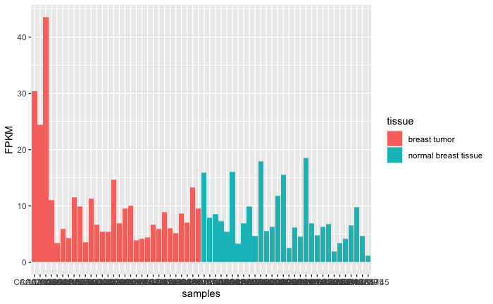

```r
data.long %>%
  filter(gene=="BRCA1") %>%
  ggplot(., aes(x=samples, y=FPKM , fill=tissue)) +
  geom_col()
```

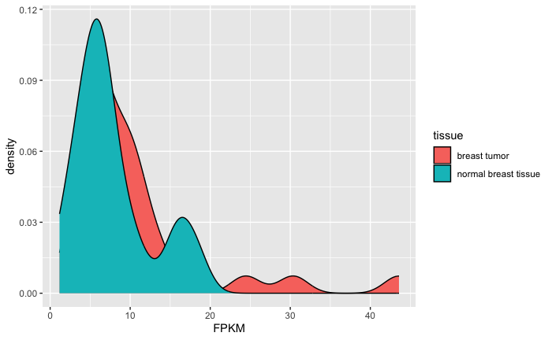

```r
data.long %>%
  filter(gene=="BRCA1") %>%
  ggplot(., aes(x=FPKM, fill=tissue)) +
  geom_density()
```

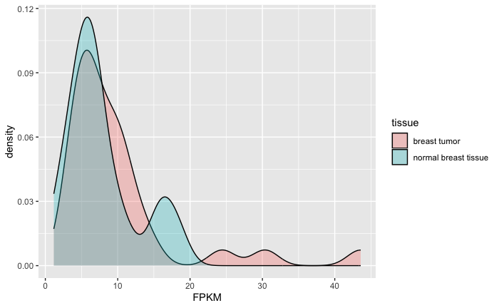

```r
data.long %>%
  filter(gene=="BRCA1") %>%
  ggplot(., aes(x=FPKM, fill=tissue)) +
  geom_density(alpha=0.3)
```